# EDA Presentation

Derek Li

2025-11-08

### Introduction and Data

Goal: Take a look at the distribution of biodiversity across the BIA and woodbine area. We focused on identifying any temporal orspatial patterns in biodiversity, vegetation, and water features that may contribute to the area’s overall environmental quality and attractiveness to visitors.

Datasets Overview:

1. iNaturalist Dataset:
- Description: Records of animal and plant species observed within the BIA boundaries from years 2020 to present.
- Key variables:
  - common_name (string)
  - iconic_taxon_name (string) - scientific categorical name
  - latitude, longitude (numeric) - coordinates of obvservation
  - observed_on (string/date) - date of observation
- Purpose: Used to assess biodiversity richness, species distribution, and possible ecological hotspots in the BIA.
2. Tree Point Dataset:
- Description: mapping of the physical locations of all trees in the BIA, obtained from Toronto Open Data.
- Key variables:
  - OBJECTID (numeric) - Unique identifier
  - LATITUDE, LONGITUDE (in geometry, numeric) - coordinates of tree
- Purpose: potentially provides insight into canopy coverage, species diversity, and potential cooling or shading effects that can enhance pedestrian comfort and street appeal.
3. Waterbody/Green Spaces Dataset:
- Description: Layer representing water features/green spaces, obtained from Toronto Open Data.
- Key variables:
  - geometry (sf) - boundaries of the waterbodies
  - AREA_NA9 (green spaces, string) - names of the green spaces
- Purpose: Used to examine proximity effects; how wildlife density or biodiversity levels may correlate with nearby natural features.

All datasets are referenced in a common coordinate reference system (EPSG:4326). All analyses were conducted within the boundaries of the BIA.

### Data Processing and Cleaning

1. iNaturalist Dataset:
- Checked for obvious duplicate observations.
- Checked for any observations with NA values in columns of interest.
- Made sure variables are consistent across all observations (e.g. format, data type)
- Filtered irrelevant observations outside of the boundaries of the BIA.
- Categorized observations based on iconic_taxon_name.
2. Tree Point Dataset
- Cropped original data to a subset which encompasses the BIA.
- Checked for obvious duplicates and NA values.
- Filtered out observations outside of the boundaries of the BIA.
3. Waterbodies/Green Spaces Dataset
- Checked for obvious duplicates and NA values.
- Filtered out observations outside of the boundaries of the BIA.

### Summaries and Plots

Summary/preview of data

```
## [1] "Number of Trees in the BIA: 8196"
```

Summary of green spaces within the BIA

| Unique ID | Green Space Category | Name | geometry (omit) |
| --- | --- | --- | --- |
| 1501 | Building Grounds | BEACHES RECREATION CENTRE - Building Grounds | MULTIPOLYGON (((-79.29892 4… |
| 1562 | Park | PANTRY PARK | MULTIPOLYGON (((-79.30192 4… |
| 1681 | Park | KEW GARDENS | MULTIPOLYGON (((-79.29877 4… |
| 1884 | Park | WOODBINE PARK | MULTIPOLYGON (((-79.31128 4… |
| 2063 | Park | MAIN SEWAGE TREATMENT PLAYGROUND | MULTIPOLYGON (((-79.31532 4… |
| 2089 | Park | GLEN STEWART PARK | MULTIPOLYGON (((-79.2914 43… |
| 2198 | Park | JEFF SLOAN PLAYGROUND | MULTIPOLYGON (((-79.31001 4… |
| 2407 | Park | MEASUREMENT PARK | MULTIPOLYGON (((-79.31247 4… |
| 2450 | Park | BEACH SKATEPARK | MULTIPOLYGON (((-79.31724 4… |
| 2469 | Park | IVAN FORREST GARDENS | MULTIPOLYGON (((-79.29331 4… |
| 3209 | Traffic Island | NEVILLE PARK CIRCLE TRAFFIC ISLAND | MULTIPOLYGON (((-79.28342 4… |

Summary of waterbodies within the BIA

| Unique ID | Waterbody Category | geometry (omit) |
| --- | --- | --- |
| 446 | waterbody | MULTIPOLYGON (((-79.29355 4… |
| 905 | waterbody | MULTIPOLYGON (((-79.31164 4… |
| 917 | waterbody | MULTIPOLYGON (((-79.31165 4… |

Preview of iNaturalist data set

| Date Observed | Scientific Name | Common Name | Species Category | geometry (omit) |
| --- | --- | --- | --- | --- |
| 2020-01-03 | Acer negundo | box elder | Plantae | POINT (-79.31649 43.6646) |
| 2020-01-03 | Acer platanoides | Norway maple | Plantae | POINT (-79.31638 43.66465) |
| 2020-01-03 | Fraxinus pennsylvanica | green ash | Plantae | POINT (-79.31661 43.66462) |
| 2020-01-05 | Buteo jamaicensis | Red-tailed Hawk | Aves | POINT (-79.32185 43.66298) |
| 2020-01-03 | Morus alba | white mulberry | Plantae | POINT (-79.31614 43.6646) |
| 2020-01-09 | Melanerpes carolinus | Red-bellied Woodpecker | Aves | POINT (-79.29358 43.6732) |
| 2020-01-12 | Necrobia rufipes | Red-legged Ham Beetle | Insecta | POINT (-79.3085 43.67065) |
| 2020-01-15 | Procyon lotor | Common Raccoon | Mammalia | POINT (-79.30051 43.6666) |
| 2020-01-26 | Procyon lotor | Common Raccoon | Mammalia | POINT (-79.29333 43.67761) |
| 2020-01-29 | Junco hyemalis | Dark-eyed Junco | Aves | POINT (-79.29159 43.67904) |

Categories of species

| Category | Number of Observations |
| --- | --- |
| Birds | 992 |
| Fungi | 60 |
| Insects | 1580 |
| Mammals | 183 |
| Other | 140 |
| Plants | 1277 |
| Reptiles | 34 |
| Spiders | 66 |

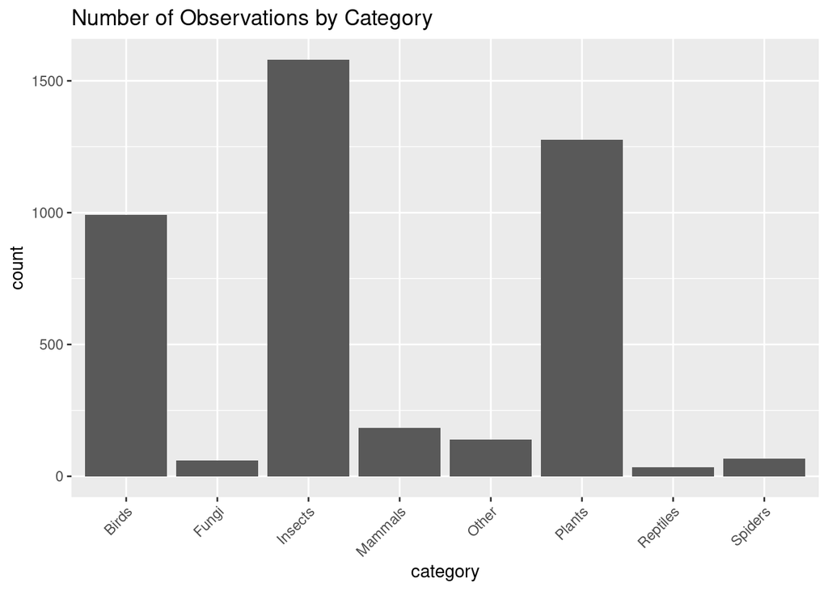

[interactive chart not shown]

iNaturalist Observations by Year

| Year | Number of Observations |
| --- | --- |
| 2020 | 704 |
| 2021 | 814 |
| 2022 | 453 |
| 2023 | 593 |
| 2024 | 559 |
| 2025 | 1209 |

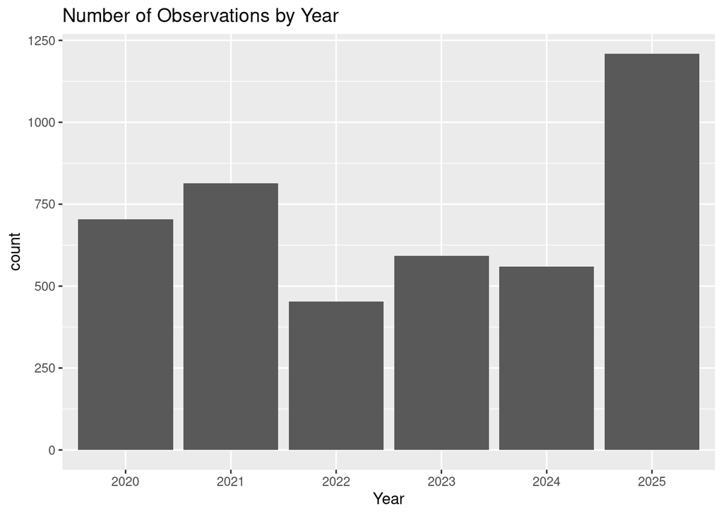

[interactive chart not shown]

Tree, Green Space, and Waterbody spatial layers

[interactive chart not shown]